# VISTA Activities 2012-16

## About

## Document

Version: May 20, 2019

This document describes the process for calculating the spread of activities of Melbournians by time of day. The Victorian Integrated Survey of Travel & Activity (VISTA) 2012-16 data is used for this purpose.

## Data

### Victorian Integrated Survey of Travel & Activity

## Sourcing VISTA 2012-16 Data

The Victorian Integrated Survey of Travel & Activity (VISTA) 2012-16 data was downloaded from the following URL on 10th May 2019:

```
https://transport.vic.gov.au/-/media/tfv-documents/vista/vista_2012_16_v1_sa1_csv.zip
```

The Zip archive was uncompressed, and the contained CSV files recompressed using GZip giving:

```
./VISTA_2012_16_v1_SA1_CSV/JTW_VISTA12_16_SA1_V1.csv.gz
./VISTA_2012_16_v1_SA1_CSV/S_VISTA12_16_SA1_V1.csv.gz
./VISTA_2012_16_v1_SA1_CSV/H_VISTA12_16_SA1_V1.csv.gz
./VISTA_2012_16_v1_SA1_CSV/P_VISTA12_16_SA1_V1.csv.gz
./VISTA_2012_16_v1_SA1_CSV/JTE_VISTA12_16_sa1_V1.csv.gz
./VISTA_2012_16_v1_SA1_CSV/T_VISTA12_16_SA1_V1.csv.gz
```

## Understanding Trip Data

We use Trip Table (`T_VISTA12_16_SA1_V1.csv`) with these select columns:

```
---------------------------------------------------------------------------
Column            Description
----------------  ---------------------------------------------------------
PERSID            Person ID number
TRAVDOW           Travel day day-of-week
ORIGPURP1         Origin Purpose (Summary)
DESTPURP1         Destination Purpose (Summary)
STARTIME          Time of Starting Trip Stage (in minutes, from midnight)
ARRTIME           Time of Ending Trip Stage (in minutes, from midnight)
CW_WDTRIPWGT_LGA  Trip weight for an 'Average weekday’ of the combined
                  2012-14 and 2014-16 ReportingPeriods, using the ASGC.
CW_WETRIPWGT_LGA  Trip weight for an 'Average weekend day' of the combined
                  2012-14 and 2014-16 ReportingPeriods, using the ASGC.
---------------------------------------------------------------------------
```

## Example Trip Record for a Person

```
--------------------------------------------------------------------------------------------
        PERSID TRAVDOW         ORIGPURP1         DESTPURP1 STARTIME ARRTIME CW_WDTRIPWGT_LGA
-------------- ------- ----------------- ----------------- -------- ------- ----------------
Y12H0000126P01  Friday     At or Go Home      Work Related      475     535           139.78
Y12H0000126P01  Friday      Work Related Personal Business      580     590           139.78
Y12H0000126P01  Friday Personal Business      Work Related      600     610           139.78
Y12H0000126P01  Friday      Work Related     At or Go Home     1050    1125           139.78
--------------------------------------------------------------------------------------------
```

## Activities by Time of Day

## Extracting Activities from Trip Records

We convert every person’s trip record:

```
--------------------------------------------------------------------------------------------
        PERSID TRAVDOW         ORIGPURP1         DESTPURP1 STARTIME ARRTIME CW_WDTRIPWGT_LGA
-------------- ------- ----------------- ----------------- -------- ------- ----------------
Y12H0000126P01  Friday     At or Go Home      Work Related      475     535           139.78
Y12H0000126P01  Friday      Work Related Personal Business      580     590           139.78
Y12H0000126P01  Friday Personal Business      Work Related      600     610           139.78
Y12H0000126P01  Friday      Work Related     At or Go Home     1050    1125           139.78
--------------------------------------------------------------------------------------------
```

To that person’s activity record like this:

```
--------------------------------------------------------------------------------------
        PERSID TRAVDOW          ACTIVITY  ACT.START.TIME ACT.END.TIME CW_WDTRIPWGT_LGA
-------------- ---------------- --------- -------------- ------------ ----------------
Y12H0000126P01  Friday     At or Go Home               0          475           139.78
Y12H0000126P01  Friday      Work Related             535          580           139.78
Y12H0000126P01  Friday Personal Business             590          600           139.78
Y12H0000126P01  Friday      Work Related             610         1050           139.78
Y12H0000126P01  Friday     At or Go Home            1125         1439           139.78
--------------------------------------------------------------------------------------
```

## Simplifying Activity Labels

Group activities into activity groups as follows:

```
----------------------------------------------------------------------------------------
Activities                                                       Activity Group
---------------------------------------------------------------- -----------------------
At or Go Home                                                    Home
Accompany Someone                                                With Someone
Change Mode                                                      Mode Change
Unknown purpose (at start of day), Other Purpose, Not Stated     Other
Personal Business                                                Personal
Work Related                                                     Work
Education                                                        Study
Buy Something                                                    Shop
Social Recreational                                              Social/Recreational
Pick-up or Drop-off Someone, Pick-up or Deliver Something        Pickup/Dropoff/Deliver
----------------------------------------------------------------------------------------
```

## Creating Activity Bins by Time of Day

1. Cut the day into fixed time bins of configurable size (30/60/120 mins)
2. For every activity record, count `CW_WDTRIPWGT_LGA` persons in every time bin that overlaps with the activity time
3. For any time bins that do not add up to the expected population (sum of `CW_WDTRIPWGT_LGA` per unique person), scale up the time bin vector of activities to the expected population size, proportionally.

   ```
   dd<-aggregate(activities,by=list(activities$Person),FUN=head,n=1)
   popnsize<-sum(dd$Count)
   actCounts<-t(apply(actCounts,1, function(x, mx) {(x/sum(x))*mx}, mx=popnsize))
   ```

## Activities by Time of Day for Greater Melbourne

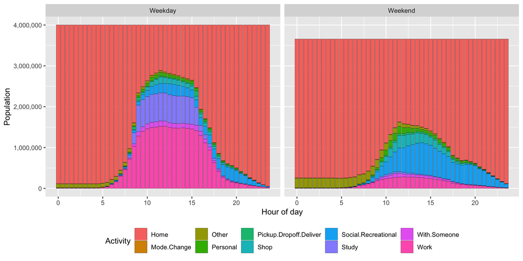

## Activity Chains

### or what follows what

## Markov Chain Model

- Start with our activity groups, but with the `Home` group refined as follows:

```
--------------------------------------------------------------------------------------
Activity Type       Mapping to VISTA Activity
------------------- ------------------------------------------------------------------
Home Morning           At or Go Home, when first activity of the day
Home Night             At or Go Home, when last activity of the day
Home Daytime           At or Go Home, when not the first or last activity of the day
Mode Change            Change Mode
Other                  Unknown purpose (at start of day), Other Purpose, Not Stated
Personal               Personal Business
Pickup/Dropoff/Deliver Pick-up or Drop-off Someone, Pick-up or Deliver Something
Shop                   Buy Something
Social/Recreational    Social, Recreational
Study                  Education
With Someone           Accompany Someone
Work                   Work Related
-------------------------------------------------------------------------------------
```

- Use VISTA data to create a matrix giving transition probabilities between each activity
- `Home Night` is the *absorbing state* as there are zero transitions out from it.
- Use the transition matrix to create a *Markov Chain* model (using R package `markovchain`)

## Weekend Activities - Markov Chain Model

[figure not shown]

## Weekend Activities - Generating New Chains

- Markov Chain model can be used to generate any number of sequences of activities, for example:

  ```r
  > c("Home Morning",rmarkovchain(n=9,mc,t0="Home Morning")) # chain of size 10
  [1] "Home Morning"        "Shop"          "Home Daytime"        "Social/Recreational"
  [5] "Social/Recreational" "Home Daytime"  "Social/Recreational" "Home Night"
  [9] "Home Night"          "Home Night"
  ```

  \(\therefore\) `Home -> Shop -> Home -> Social/Rec -> Social/Rec -> Home -> Social/Rec -> Home`.

## Generating Weekend Activities for 15,000 Persons

```r
popnsz<-15000; chainlen<-50; startAct<-"Home Morning"; endAct<-"Home Night"
df<-data.frame(row.names = seq(1:chainlen))
for (i in seq(1:popnsz)) {
  v<-c(startAct,rmarkovchain(n=chainlen-1,mc,t0=startAct)) # chain of requested length
  idx<-match(endAct, v); v[seq(idx+1,length(v))]<-'' # remove repeating endActs
  df[,i]<-v # assign to new column
}
acts<-as.data.frame(table(t(df))) # return the transposed matrix and summarise
acts<-acts[2:nrow(acts),] # remove first row of total counts
acts$Percentage<-round(100*(acts$Freq/sum(acts$Freq)),digits = 1) # get percentage split
print(acts[order(acts$Percentage, decreasing = TRUE),]) # report
```

```
##                      Var1  Freq Percentage
## 3            Home Morning 15000       21.3
## 4              Home Night 15000       21.3
## 10    Social/Recreational 13261       18.8
## 9                    Shop  9086       12.9
## 2            Home Daytime  7529       10.7
## 8  Pickup/Dropoff/Deliver  3302        4.7
## 7                Personal  3008        4.3
## 13                   Work  2041        2.9
## 12           With Someone  1540        2.2
## 6                   Other   305        0.4
## 11                  Study   288        0.4
## 5             Mode Change     3        0.0
```